# fishing effort data

1 November 2021

These are the data that Jordan Watson procured for us from AKFIN. We want to take a look at the data from the fishing effort and incorporate that into the fulmar bycatch distributions.

The first goal would be to make a map that looks like the bycatch map, but shows the spatial distribution of fishing effort.

```r
library(tidyverse)
library(dplyr)
library(adehabitatHR)
library(ggplot2)
library(magrittr)
library(sp)
library(raster)
library(marmap)
library(mapdata)

library(spData)
```

```r
fishing <- readRDS("extdata/longline_effort_halfdegree_bins_diana_w_hooks.RDS") %>%
  mutate(season = ifelse(month %in% c(5:9), "breeding", "nonbreeding"))

fish_by_hooks <- fishing %>%
  group_by(season, lonr, latr) %>%
  summarise(sum(hooks)) %>%
  rename(tot_hooks = `sum(hooks)`)
```

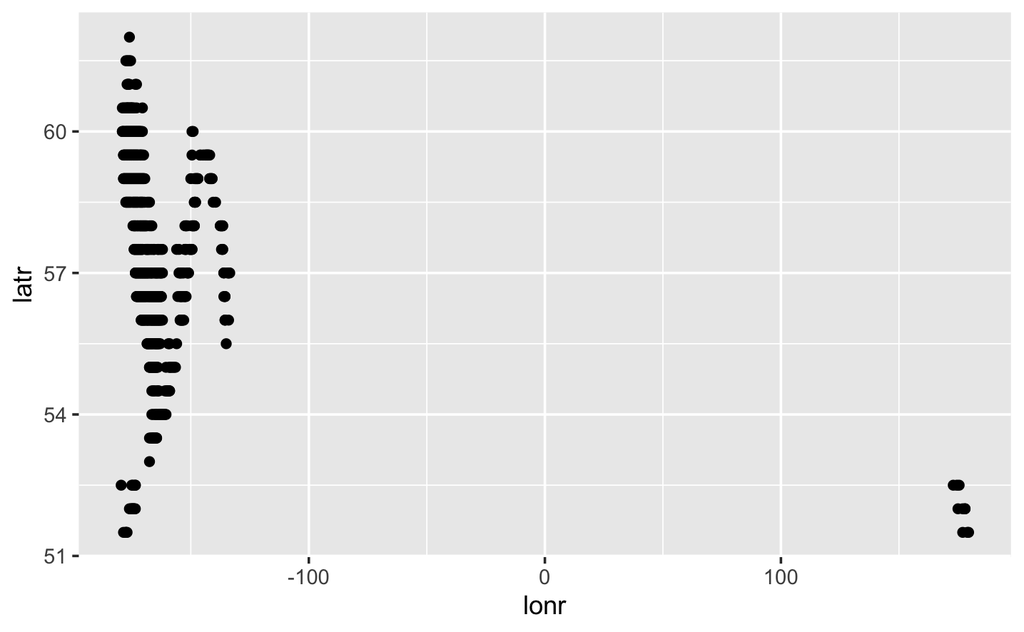

```r
ggplot(fish_by_hooks) +
  geom_point(aes(x = lonr, y = latr))
```

Flip the sign on the data points with the wrong longitude.

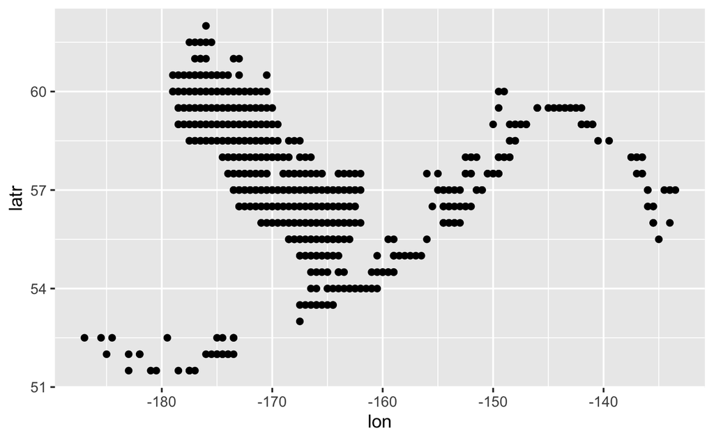

```r
fish_effort <- fish_by_hooks %>%
  mutate(lon = ifelse(lonr > 0, (360-lonr)*-1, lonr))

fish_effort %>% # deal with the international date line
  ggplot(aes(x = lon, y = latr)) +
  geom_point()
```

Quick check: What is the max N latitude?

```r
fish_effort %>%
  arrange(desc(latr)) # is this bec of the original data dump from Jordan?
```

| season | lonr | latr | tot_hooks | lon |
| --- | --- | --- | --- | --- |
| nonbreeding | -176.0 | 62.0 | 593957 | -176.0 |
| nonbreeding | -177.5 | 61.5 | 108415 | -177.5 |
| nonbreeding | -177.0 | 61.5 | 754283 | -177.0 |
| nonbreeding | -176.5 | 61.5 | 956966 | -176.5 |
| nonbreeding | -176.0 | 61.5 | 563783 | -176.0 |
| nonbreeding | -175.5 | 61.5 | 732390 | -175.5 |
| breeding | -176.5 | 61.0 | 643693 | -176.5 |
| breeding | -176.0 | 61.0 | 229173 | -176.0 |
| breeding | -173.5 | 61.0 | 528854 | -173.5 |
| breeding | -173.0 | 61.0 | 740831 | -173.0 |

[output cut: 555 more lines]

Okay, I need to think about how to weight the number of hooks…

First, maybe look at the distribution of hooks?

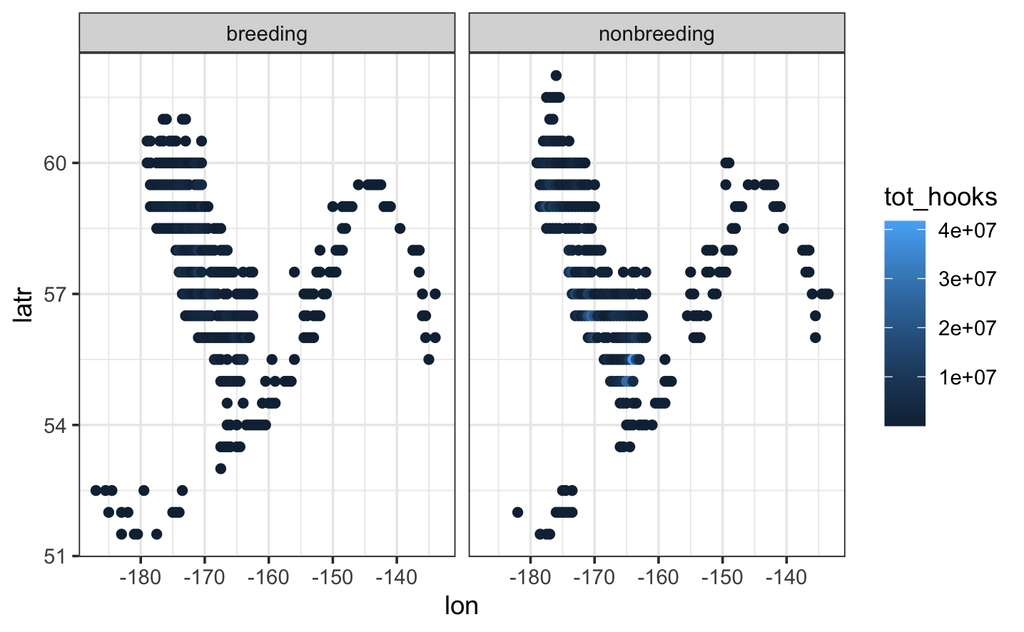

```r
fish_effort %>%
  ggplot(aes(x = lon, y = latr, color = tot_hooks)) +
  geom_point() +
  facet_wrap(~season) +
  theme_bw()
```

### spatial data projections

```r
### define projections
# input_proj <- "+proj=longlat +datum=WGS84" ###the input projection of track points
# desired_proj <- "+proj=aea +lat_1=55 +lat_2=65 +lat_0=50 +lon_0=-154 +x_0=0 +y_0=0 +ellps=GRS80 +datum=NAD83 +units=m +no_defs" ###the desired projection for track points
#
# ### convert data to a spatial object and reproject to desired coordinate system
# coordinates(fishing_season2) = ~lonr+latr ### define the x and y spatial fields
# proj4string(fishing_season2) <- CRS(input_proj) ### define the projection
# fish_effort_tr <- spTransform(fishing_season2, CRS(desired_proj)) ###transform to desired projection
#
# # another quick plot
# plot(fish_effort_tr, pch = 19, cex = 0.5)
```

I have two forms of effort - 1. the number of vessels in a given geographic area (similar to the way the bycatch fulmars were treated) 2. the number of hooks each vessel set

I think what makes more sense is to use hooks integrated across space as our measure of effort. I’m going to need to tweak the code that I had used for the fulmar kerneling because in that case, each data point was one bird with one set of lat/lon, whereas for this, each spatial datapoint corresponds to many many hooks.

Add bathymetric map

```r
# antimeridian region
aleu <- marmap::getNOAA.bathy(179, -135, 50, 67, resolution = 4,
antimeridian = TRUE)
```

```
Querying NOAA database ...
This may take seconds to minutes, depending on grid size
Building bathy matrix ...
```

```r
# Make it a raster
#bathy <- as.raster(aleu)

# Create a xyz table for ggplot
#bath<-fortify(aleu)
```

### bathymetry

this mapping from: https://hansenjohnson.org/post/bathymetric-maps-in-r/

```r
library(oce)
library(ocedata)
data("coastlineWorldFine")

# convert bathymetry
# bathyLon = as.numeric(rownames(aleu))
# bathyLat = as.numeric(colnames(aleu))
# bathyZ = as.numeric(aleu)
# dim(bathyZ) = dim(aleu)


# define plotting region
mlon = mean(fish_effort$lon)
mlat = mean(fish_effort$latr)
span = 2000
```

```r
# fishing_season2 %>%
#   ggplot(aes(x = lonr, y = latr)) +
#   geom_point(size = 0.1) +
#   stat_density2d(
#     aes(fill = stat(level)),
#     geom = "polygon",
#     contour_var = "density",
#     contour_type = "bands",
#     alpha = 0.7,
#   ) +
#     scale_fill_gradient(low = "yellow", high = "red") + scale_alpha(range = c(0.00, 0.25), guide = FALSE)
```

```r
#qBins <- quantile(fish_by_hooks$tot_hooks)
```

```r
fish_effort %>%
  group_by(season) %>%
  summarise(sum(tot_hooks)) %>%
  mutate(tot_hooks_across_seasons = sum(`sum(tot_hooks)`)) %>%
  mutate(hooks_per_month = ifelse(season == "breeding", `sum(tot_hooks)`/5, `sum(tot_hooks)`/7))
```

|  | season | sum(tot_hooks) | tot_hooks_across_seasons | hooks_per_month |
| --- | --- | --- | --- | --- |
| 1 | breeding | 395635560 | 1166960366 | 79127112 |
| 2 | nonbreeding | 771324806 | 1166960366 | 110189258 |

```r
  # mutate(prop_effort = ifelse(season == "breeding", `sum(tot_hooks)`/tot_hooks_across_seasons, `sum(tot_hooks)`/tot_hooks_across_seasons))
```

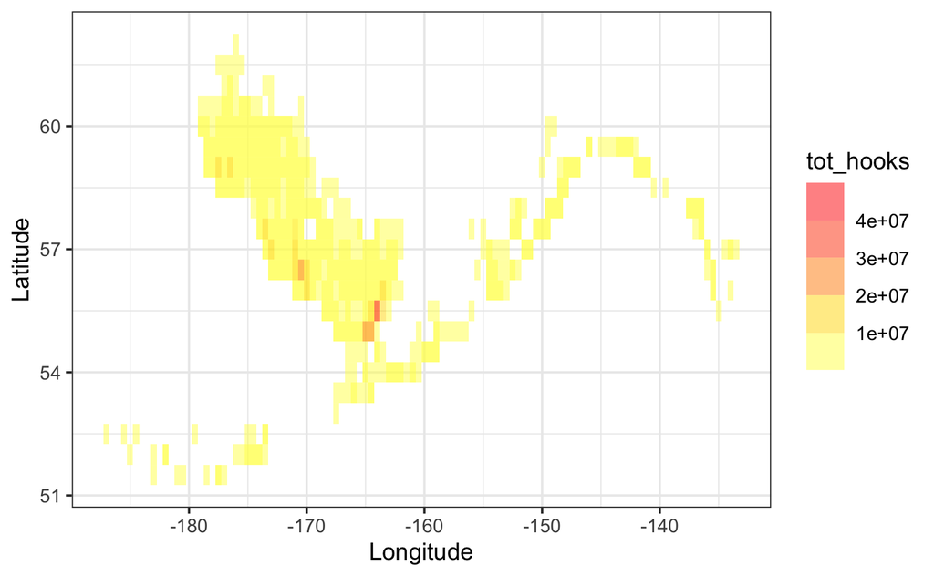

```r
fish_effort %>%
  ggplot(aes(x = lon, y = latr)) +
  #geom_point(size = 0.1) +
  geom_tile(
    aes(x = lon, y = latr, fill = tot_hooks),
    alpha = 0.5,
  ) +
    scale_fill_stepsn(colors = heat.colors(5, alpha = 0.5, rev = TRUE))+
  theme_bw() +
  xlab("Longitude") +
  ylab("Latitude")
```

I don’t want a density map. Basically, I have a numeric variable that I want to plot as the gradient fill on the map (rather than computing the density of observations).

```r
#plot(spdf)
# I need to fortify the data
library(broom)
require(mapdata)

aleu.fort <- marmap::fortify.bathy(aleu)

# get regional polygons
reg = map_data("world2Hires")
region = subset(reg, region %in% c('USA', 'Canada'))

# filter
ak <- region %>%
  filter(lat > 50 & lat < 65, long < 240)
```

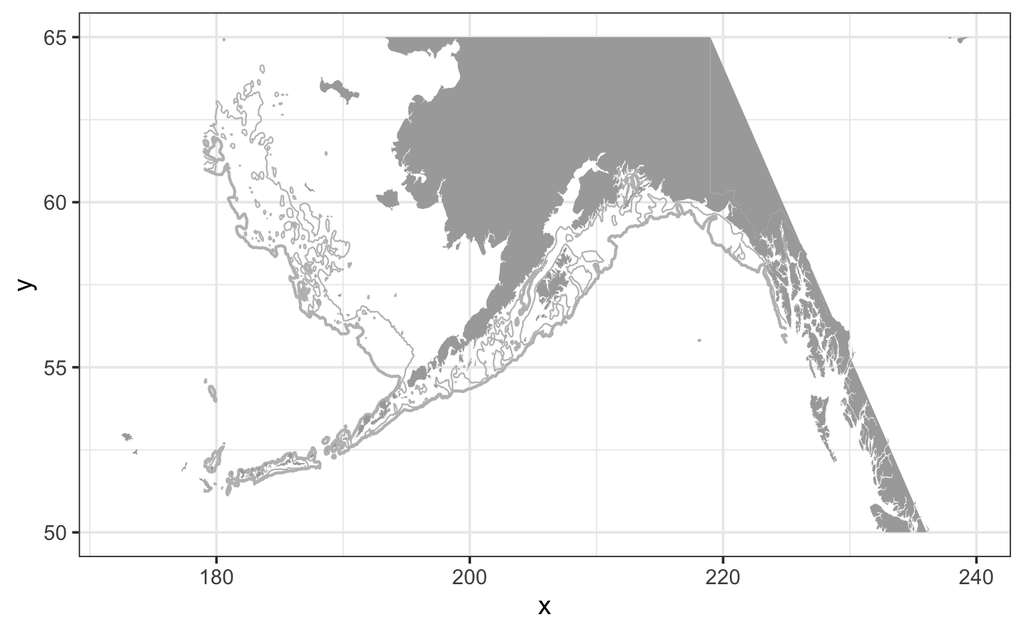

```r
# set map limits
#lons = c(-180, -135)
#lats = c(45, 65)

# plot
ggplot() +
 # add 100m contour
  geom_contour(data = aleu.fort,
               aes(x=x, y=y, z=z),
               breaks=c(-100),
               size=c(0.3),
               colour="grey") +

  # add 250m contour
  geom_contour(data = aleu.fort,
               aes(x=x, y=y, z=z),
               breaks=c(-250),
               size=c(0.6),
               colour="grey") +

  # add coastline
  geom_polygon(data = ak, aes(x = long, y = lat, group = group),
               fill = "darkgrey", color = NA) +
  theme_bw()
```

```r
#formatting
breaks <- c(5000, 10000, 50000, 100000, 500000, 1000000, 5000000)
custom_bins <- quantile(fish_effort$tot_hooks, probs=c(0,.2,.4,.6,.8,1))


fish_by_hooks_df <- mutate(fish_effort, hooks=cut(tot_hooks, breaks=custom_bins))
fish_by_hooks_df1 <- fish_by_hooks_df %>%
  filter(!is.na(hooks))
```

```r
# get regional polygons
reg = map_data("world2Hires")
regions = subset(reg, region %in% c('USA', 'Canada')) %>%
  filter(lat > 47 & lat < 65, long < 240)

# convert lat longs
regions$long = (360 - regions$long)*-1

# set map limits
lons = c(-188, -140) #this needs to extend beyond the date line
lats = c(50, 61.75)
```

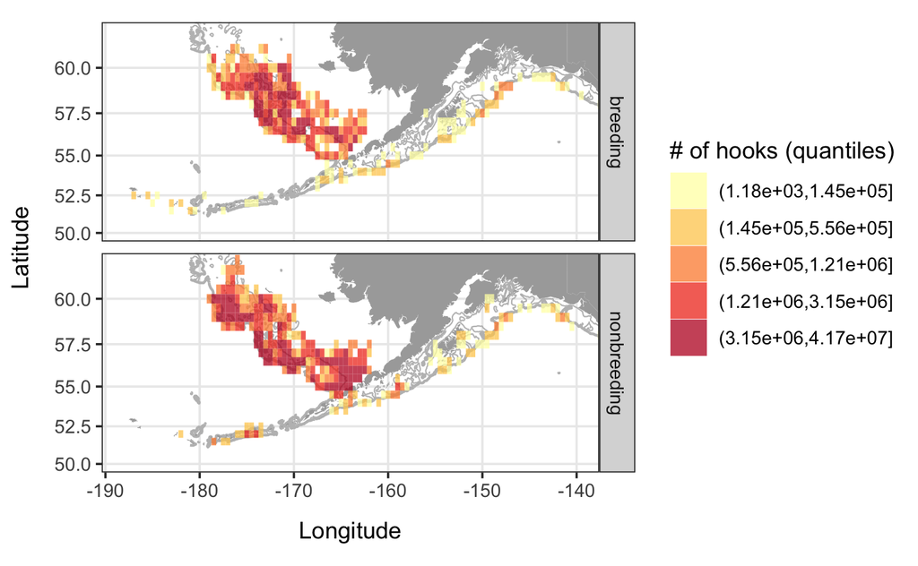

```r
library(ggplot2)
# make plot
ggplot()+

  # add 100m contour
  geom_contour(data = aleu.fort,
               aes(x=x, y=y, z=z),
               breaks=c(-100),
               size=c(0.3),
               colour="grey") +

  # add 250m contour
  geom_contour(data = aleu.fort,
               aes(x=x, y=y, z=z),
               breaks=c(-250),
               size=c(0.6),
               colour="grey") +

  # add coastline
  geom_polygon(data = regions, aes(x = long, y = lat, group = group),
               fill = "darkgrey", color = NA) +

  # add hooks (fishing effort)
  geom_tile(data = fish_by_hooks_df1,
    aes(x = lon, y = latr, fill = hooks),
    alpha = 0.75,
  ) +
    #scale_fill_gradient(low = "yellow", high = "red")+
  #scale_fill_stepsn(colors = RColorBrewer::brewer.pal(5, "YlOrRd"), breaks = custom_bins) +
  scale_fill_brewer(palette = "YlOrRd") +
   # facet seasons
  facet_grid(rows = vars(season)) +

  # configure projection and plot domain
  coord_map(xlim = lons, ylim = lats)+


  # formatting
  xlab("Longitude") +
  ylab("Latitude") +
  labs(fill = "# of hooks (quantiles)") +
  theme_bw()+
  theme(
    axis.title.x = element_text(margin = margin(t=10)),
    axis.title.y = element_text(margin = margin(r=10))
  )
```

```r
 # manually set the text for the legend.

#ggsave("pdf_outputs/fishing_effort_map_season.pdf", width = 7, height = 9)
```

Make the same maps, but zoom in so the spatial extent matches the utilization distribution maps for the colonies:

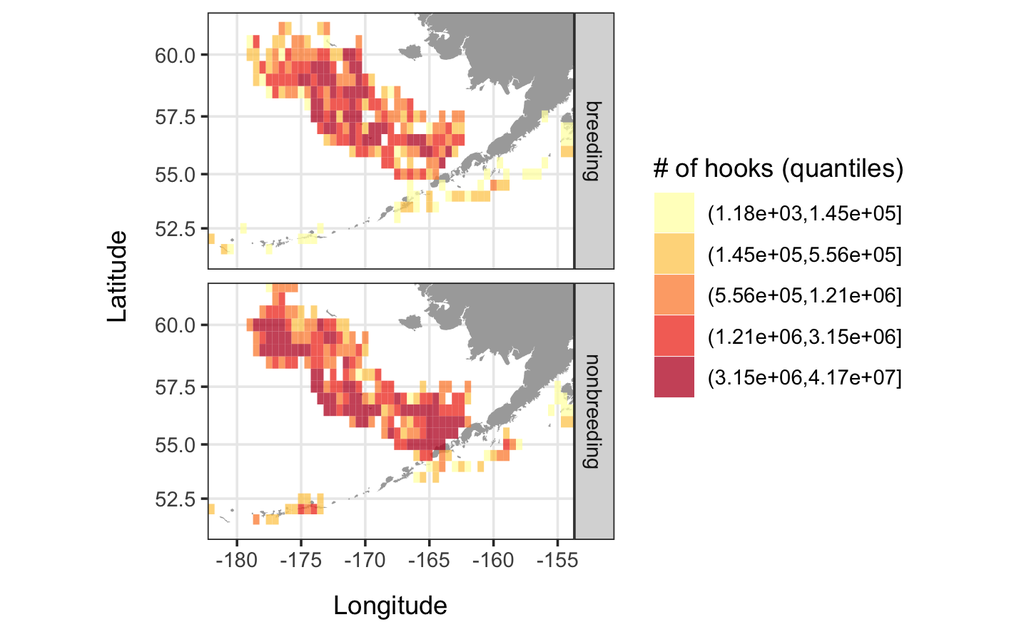

```r
# set map limits
lons = c(-181, -155) #this needs to extend beyond the date line
lats = c(51, 61.1)

# make plot
ggplot()+

  # add 100m contour
  # geom_contour(data = aleu.fort,
  #              aes(x=x, y=y, z=z),
  #              breaks=c(-100),
  #              size=c(0.3),
  #              colour="grey") +
  #
  # # add 250m contour
  # geom_contour(data = aleu.fort,
  #              aes(x=x, y=y, z=z),
  #              breaks=c(-250),
  #              size=c(0.6),
  #              colour="grey") +
  #
  # add coastline
  geom_polygon(data = regions, aes(x = long, y = lat, group = group),
               fill = "darkgrey", color = NA) +

  # add hooks (fishing effort)
  geom_tile(data = fish_by_hooks_df1,
    aes(x = lon, y = latr, fill = hooks),
    alpha = 0.75,
  ) +
    #scale_fill_gradient(low = "yellow", high = "red")+
  #scale_fill_stepsn(colors = RColorBrewer::brewer.pal(5, "YlOrRd"), breaks = custom_bins) +
  scale_fill_brewer(palette = "YlOrRd") +
   # facet seasons
  facet_grid(rows = vars(season)) +

  # configure projection and plot domain
  coord_map(xlim = lons, ylim = lats)+


  # formatting
  xlab("Longitude") +
  ylab("Latitude") +
  labs(fill = "# of hooks (quantiles)") +
  theme_bw()+
  theme(
    axis.title.x = element_text(margin = margin(t=10)),
    axis.title.y = element_text(margin = margin(r=10))
  )

ggsave("pdf_outputs/fishing_effort_map_season_zoomed.pdf", width = 7, height = 9)
```

```r
# make plot
test.map <- ggplot()+

  # add 100m contour
  geom_contour(data = aleu.fort,
               aes(x=x, y=y, z=z),
               breaks=c(-100),
               size=c(0.3),
               colour="grey") +

  # add 250m contour
  geom_contour(data = aleu.fort,
               aes(x=x, y=y, z=z),
               breaks=c(-250),
               size=c(0.6),
               colour="grey") +

  # add coastline
  geom_polygon(data = regions, aes(x = long, y = lat, group = group),
               fill = "darkgrey", color = NA) +

  # add UD polygon
  # geom_polygon(data = prib.nob,
  #   aes(x = long, y = lat, fill = group),
  #   alpha = 0.5) +
  #
  # configure projection and plot domain
  coord_map(xlim = lons, ylim = lats)+



  # formatting
  xlab("Longitude") +
  ylab("Latitude") +
  labs(fill = "# of hooks (quantiles)") +
  theme_bw()+
  theme(
    axis.title.x = element_text(margin = margin(t=10)),
    axis.title.y = element_text(margin = margin(r=10))
  )
```

Can I zoom in more on that?

```r
region.zoom <- regions %>%
  filter(long < -145, long > -181, lat > 50, lat < 62)
```

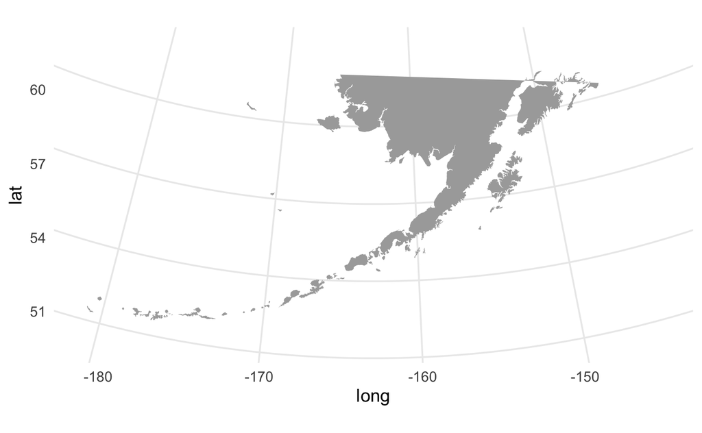

```r
albers.ak.map <- ggplot() +
  geom_polygon(data = region.zoom, aes(x = long, y = lat, group = group),
               fill = "darkgrey", color = NA) +
  coord_map(projection = "albers", par=55,62) +
  theme_minimal()

albers.ak.map

ggsave("pdf_outputs/albers_map_ak.pdf")
```

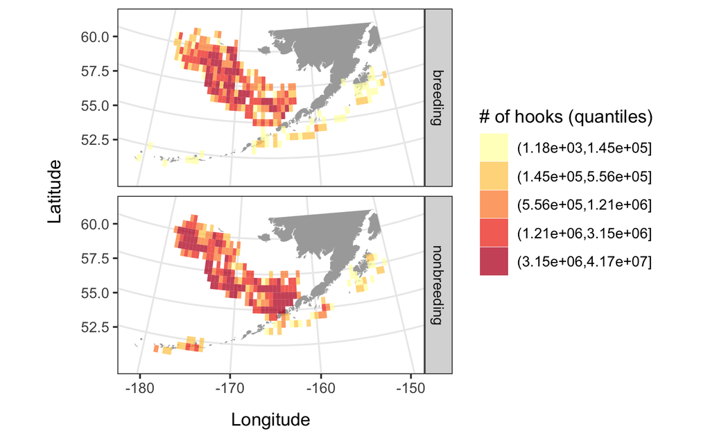

```r
# zoom in on the effort data too
fish_by_hooks_to_plot <- fish_by_hooks_df1 %>%
  filter(lon < -145, lon > -181, latr > 50, latr < 62)

albers.ak.map +
# add hooks (fishing effort)
  geom_tile(data = fish_by_hooks_df1,
    aes(x = lon, y = latr, fill = hooks),
    alpha = 0.75,
  ) +
  ylim(c(51,61.5)) +
  xlim(c(-181,-150)) +
    #scale_fill_gradient(low = "yellow", high = "red")+
  #scale_fill_stepsn(colors = RColorBrewer::brewer.pal(5, "YlOrRd"), breaks = custom_bins) +
  scale_fill_brewer(palette = "YlOrRd") +
   # facet seasons
  facet_grid(rows = vars(season)) +

  # configure projection and plot domain
  #coord_map(xlim = lons, ylim = lats)+


  # formatting
  xlab("Longitude") +
  ylab("Latitude") +
  labs(fill = "# of hooks (quantiles)") +
  theme_bw()+
  theme(
    axis.title.x = element_text(margin = margin(t=10)),
    axis.title.y = element_text(margin = margin(r=10))
  )

ggsave("pdf_outputs/hooks_effot_aea_proj.pdf", width = 7, height = 9)
```